# BellaBeat Fitness Tracker Analysis

# Introduction

BellaBeat is a high-tech company that manufactures health-focused smart products. This analysis considers the marketing and product strategies that BellaBeat should consider for the products **Time**- a wellness watch with smart technology to track user activity, sleep, and stress, and **Leaf** - Bellabeat’s classic wellness tracker that can be worn as a bracelet, necklace, or clip and tracks activity, sleep, and stress.

### Buisiness Tasks

BellaBeat has asked the following:

- What are some trends in smart device usage?
- How could these trends apply to Bellabeat customers?
- How could these trends help influence Bellabeat marketing strategy?

### Findings

Through this analysis, the following takeaways should be noted:

# Organizing and Cleaning the data

### A Quick View of the data

Here is a quick view of some of the data:

```r
tibble(dailyActivity_merged)
```

```
## # A tibble: 940 × 15
##            Id Activity…¹ Total…² Total…³ Track…⁴ Logge…⁵ VeryA…⁶ Moder…⁷ Light…⁸
##         <dbl> <chr>        <int>   <dbl>   <dbl>   <dbl>   <dbl>   <dbl>   <dbl>
##  1 1503960366 4/12/2016    13162    8.5     8.5        0    1.88   0.550    6.06
##  2 1503960366 4/13/2016    10735    6.97    6.97       0    1.57   0.690    4.71
##  3 1503960366 4/14/2016    10460    6.74    6.74       0    2.44   0.400    3.91
##  4 1503960366 4/15/2016     9762    6.28    6.28       0    2.14   1.26     2.83
##  5 1503960366 4/16/2016    12669    8.16    8.16       0    2.71   0.410    5.04
##  6 1503960366 4/17/2016     9705    6.48    6.48       0    3.19   0.780    2.51
##  7 1503960366 4/18/2016    13019    8.59    8.59       0    3.25   0.640    4.71
##  8 1503960366 4/19/2016    15506    9.88    9.88       0    3.53   1.32     5.03
##  9 1503960366 4/20/2016    10544    6.68    6.68       0    1.96   0.480    4.24
## 10 1503960366 4/21/2016     9819    6.34    6.34       0    1.34   0.350    4.65
## # … with 930 more rows, 6 more variables: SedentaryActiveDistance <dbl>,
## #   VeryActiveMinutes <int>, FairlyActiveMinutes <int>,
## #   LightlyActiveMinutes <int>, SedentaryMinutes <int>, Calories <int>, and
## #   abbreviated variable names ¹ActivityDate, ²TotalSteps, ³TotalDistance,
## #   ⁴TrackerDistance, ⁵LoggedActivitiesDistance, ⁶VeryActiveDistance,
## #   ⁷ModeratelyActiveDistance, ⁸LightActiveDistance
```

```r
tibble(sleepDay_merged)
```

```
## # A tibble: 413 × 5
##            Id SleepDay   TotalSleepRecords TotalMinutesAsleep TotalTimeInBed
##         <dbl> <chr>                  <int>              <int>          <int>
##  1 1503960366 2016-04-12                 1                327            346
##  2 1503960366 2016-04-13                 2                384            407
##  3 1503960366 2016-04-15                 1                412            442
##  4 1503960366 2016-04-16                 2                340            367
##  5 1503960366 2016-04-17                 1                700            712
##  6 1503960366 2016-04-19                 1                304            320
##  7 1503960366 2016-04-20                 1                360            377
##  8 1503960366 2016-04-21                 1                325            364
##  9 1503960366 2016-04-23                 1                361            384
## 10 1503960366 2016-04-24                 1                430            449
## # … with 403 more rows
```

```r
tibble(timeIntensities)
```

```
## # A tibble: 22,099 × 5
##            Id ActivityHour Time   TotalIntensity AverageIntensity
##         <dbl> <date>       <time>          <dbl>            <dbl>
##  1 1503960366 2016-04-12   00:00              20            0.333
##  2 1503960366 2016-04-12   01:00               8            0.133
##  3 1503960366 2016-04-12   02:00               7            0.117
##  4 1503960366 2016-04-12   03:00               0            0
##  5 1503960366 2016-04-12   04:00               0            0
##  6 1503960366 2016-04-12   05:00               0            0
##  7 1503960366 2016-04-12   06:00               0            0
##  8 1503960366 2016-04-12   07:00               0            0
##  9 1503960366 2016-04-12   08:00              13            0.217
## 10 1503960366 2016-04-12   09:00              30            0.5
## # … with 22,089 more rows
```

### Cleaning the data

```r
realActivity <-dailyActivity_merged %>%
  filter(TotalSteps>100,Calories>500)

glimpse(realActivity)
```

```
## Rows: 852
## Columns: 15
## $ Id                       <dbl> 1503960366, 1503960366, 1503960366, 150396036…
## $ ActivityDate             <chr> "4/12/2016", "4/13/2016", "4/14/2016", "4/15/…
## $ TotalSteps               <int> 13162, 10735, 10460, 9762, 12669, 9705, 13019…
## $ TotalDistance            <dbl> 8.50, 6.97, 6.74, 6.28, 8.16, 6.48, 8.59, 9.8…
## $ TrackerDistance          <dbl> 8.50, 6.97, 6.74, 6.28, 8.16, 6.48, 8.59, 9.8…
## $ LoggedActivitiesDistance <dbl> 0, 0, 0, 0, 0, 0, 0, 0, 0, 0, 0, 0, 0, 0, 0, …
## $ VeryActiveDistance       <dbl> 1.88, 1.57, 2.44, 2.14, 2.71, 3.19, 3.25, 3.5…
## $ ModeratelyActiveDistance <dbl> 0.55, 0.69, 0.40, 1.26, 0.41, 0.78, 0.64, 1.3…
## $ LightActiveDistance      <dbl> 6.06, 4.71, 3.91, 2.83, 5.04, 2.51, 4.71, 5.0…
## $ SedentaryActiveDistance  <dbl> 0, 0, 0, 0, 0, 0, 0, 0, 0, 0, 0, 0, 0, 0, 0, …
## $ VeryActiveMinutes        <int> 25, 21, 30, 29, 36, 38, 42, 50, 28, 19, 66, 4…
## $ FairlyActiveMinutes      <int> 13, 19, 11, 34, 10, 20, 16, 31, 12, 8, 27, 21…
## $ LightlyActiveMinutes     <int> 328, 217, 181, 209, 221, 164, 233, 264, 205, …
## $ SedentaryMinutes         <int> 728, 776, 1218, 726, 773, 539, 1149, 775, 818…
## $ Calories                 <int> 1985, 1797, 1776, 1745, 1863, 1728, 1921, 203…
```

The dates in dailyActivity_merged and sleepDay_merged are saved as characters, and are not in the correct format. These will be changed to be as class “date” in year-month-day format.

```r
realActivity$ActivityDate<-as.Date(realActivity$ActivityDate,"%m/%d/%Y")
realActivity$Date<-realActivity$ActivityDate
sleepDay_merged$SleepDay <- as.Date(sleepDay_merged$SleepDay,"%Y-%m-%d")
sleepDay_merged$Date <- sleepDay_merged$SleepDay
timeIntensities <- timeIntensities %>%
  rename("ADate"="ActivityHour")
```

I also added a new column in each data set named “NewId”, and checked that all records still contained a unique ID. This was for aesthetic purposes when graphing:

```r
realActivity$NewId <- str_extract(realActivity$Id,"\\d{5}$")
n_distinct(realActivity$Id)
```

```
## [1] 33
```

```r
n_distinct(realActivity$NewId)
```

```
## [1] 33
```

```r
sleepDay_merged$NewId <- str_extract(sleepDay_merged$Id,"\\d{5}$")
n_distinct(sleepDay_merged$Id)
```

```
## [1] 24
```

```r
n_distinct(sleepDay_merged$NewId)
```

```
## [1] 24
```

```r
timeIntensities$NewId <-str_extract(timeIntensities$Id,"\\d{5}$")
head(timeIntensities)
```

```
## # A tibble: 6 × 6
##           Id ADate      Time   TotalIntensity AverageIntensity NewId
##        <dbl> <date>     <time>          <dbl>            <dbl> <chr>
## 1 1503960366 2016-04-12 00:00              20            0.333 60366
## 2 1503960366 2016-04-12 01:00               8            0.133 60366
## 3 1503960366 2016-04-12 02:00               7            0.117 60366
## 4 1503960366 2016-04-12 03:00               0            0     60366
## 5 1503960366 2016-04-12 04:00               0            0     60366
## 6 1503960366 2016-04-12 05:00               0            0     60366
```

```r
n_distinct(timeIntensities$NewId)
```

```
## [1] 33
```

```r
n_distinct(timeIntensities$Id)
```

```
## [1] 33
```

Finally, I created a new data frame SleepActivity by merging realActivity and SleepDay_merged inner joined on ID and Date

```r
SleepActivity <- merge(realActivity,sleepDay_merged,by=c("Id","Date"))
sedmin <- SleepActivity$SedentaryMinutes
sleepTime <- SleepActivity$TotalMinutesAsleep

glimpse(SleepActivity)
```

```
## Rows: 411
## Columns: 22
## $ Id                       <dbl> 1503960366, 1503960366, 1503960366, 150396036…
## $ Date                     <date> 2016-04-12, 2016-04-13, 2016-04-15, 2016-04-…
## $ ActivityDate             <date> 2016-04-12, 2016-04-13, 2016-04-15, 2016-04-…
## $ TotalSteps               <int> 13162, 10735, 9762, 12669, 9705, 15506, 10544…
## $ TotalDistance            <dbl> 8.50, 6.97, 6.28, 8.16, 6.48, 9.88, 6.68, 6.3…
## $ TrackerDistance          <dbl> 8.50, 6.97, 6.28, 8.16, 6.48, 9.88, 6.68, 6.3…
## $ LoggedActivitiesDistance <dbl> 0, 0, 0, 0, 0, 0, 0, 0, 0, 0, 0, 0, 0, 0, 0, …
## $ VeryActiveDistance       <dbl> 1.88, 1.57, 2.14, 2.71, 3.19, 3.53, 1.96, 1.3…
## $ ModeratelyActiveDistance <dbl> 0.55, 0.69, 1.26, 0.41, 0.78, 1.32, 0.48, 0.3…
## $ LightActiveDistance      <dbl> 6.06, 4.71, 2.83, 5.04, 2.51, 5.03, 4.24, 4.6…
## $ SedentaryActiveDistance  <dbl> 0, 0, 0, 0, 0, 0, 0, 0, 0, 0, 0, 0, 0, 0, 0, …
## $ VeryActiveMinutes        <int> 25, 21, 29, 36, 38, 50, 28, 19, 41, 39, 73, 3…
## $ FairlyActiveMinutes      <int> 13, 19, 34, 10, 20, 31, 12, 8, 21, 5, 14, 23,…
## $ LightlyActiveMinutes     <int> 328, 217, 209, 221, 164, 264, 205, 211, 262, …
## $ SedentaryMinutes         <int> 728, 776, 726, 773, 539, 775, 818, 838, 732, …
## $ Calories                 <int> 1985, 1797, 1745, 1863, 1728, 2035, 1786, 177…
## $ NewId.x                  <chr> "60366", "60366", "60366", "60366", "60366", …
## $ SleepDay                 <date> 2016-04-12, 2016-04-13, 2016-04-15, 2016-04-…
## $ TotalSleepRecords        <int> 1, 2, 1, 2, 1, 1, 1, 1, 1, 1, 1, 1, 1, 1, 1, …
## $ TotalMinutesAsleep       <int> 327, 384, 412, 340, 700, 304, 360, 325, 361, …
## $ TotalTimeInBed           <int> 346, 407, 442, 367, 712, 320, 377, 364, 384, …
## $ NewId.y                  <chr> "60366", "60366", "60366", "60366", "60366", …
```

# Analysis

Several variables were analyzed from the data collected from participants wearing a fitbit. Total Steps and Burned Calories were analyzed to gauge overall health and activity of participants. Time of exercise preference was analyzed for marketing. Effects on sleep time was also analyzed for product suggestion and market purposes.

### Steps and Calories

Overall, participants in this survey had a mean number of steps of 8426 steps. This data was slightly skewed however, so analyzing the median of 8115 steps is more appropriate. Below is a histogram of the Total Steps recorded each day, along with the summary statistics:

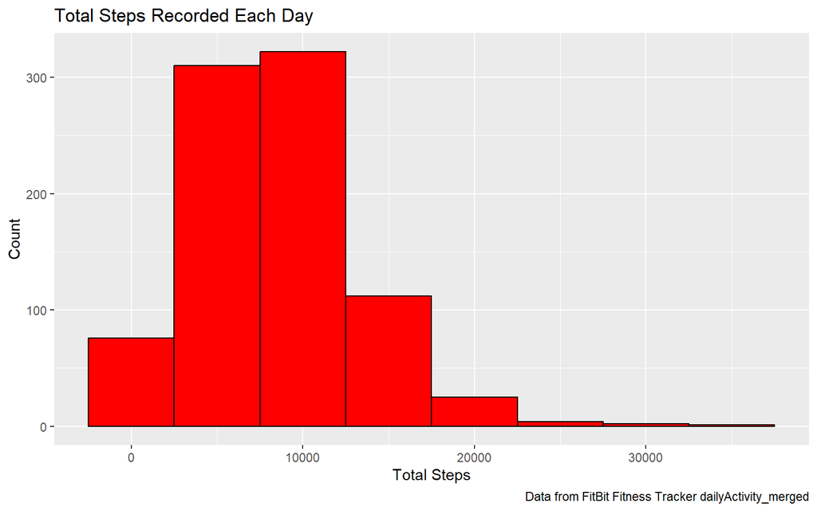

```r
ggplot(data = realActivity) +
  geom_histogram(mapping=aes(x=TotalSteps),binwidth = 5000,color="black",fill="red")+
  labs(title="Total Steps Recorded Each Day", caption = "Data from FitBit Fitness Tracker dailyActivity_merged",x="Total Steps",y="Count")
```

```r
summary(realActivity$TotalSteps)
```

```
##    Min. 1st Qu.  Median    Mean 3rd Qu.    Max.
##     108    4989    8115    8426   11114   36019
```

This seems to support [John Hopkins Medincine’s Report](https://www.hopkinsmedicine.org/health/wellness-and-prevention/could-a-fitness-tracker-boost-your-heart-health#:~:text=A%20fitness%20tracker%20may%20help,a%20heart%2Dsmart%20daily%20goal.) that fitness trackers seem to increase step counts from the average american’s 1500-2000 steps per day. This number of steps could lead to lower mortality risk as reported in an artical published by the Lancet “Daily Steps and all-cause Mortality: a meta-analysis of 15 international cohorts”. **This should be a point of advertisement for BellaBeat’s fitness trackers.**

Participants also burned a median of 2225 calories each day. This is shown in the histogram and summary statistics below:

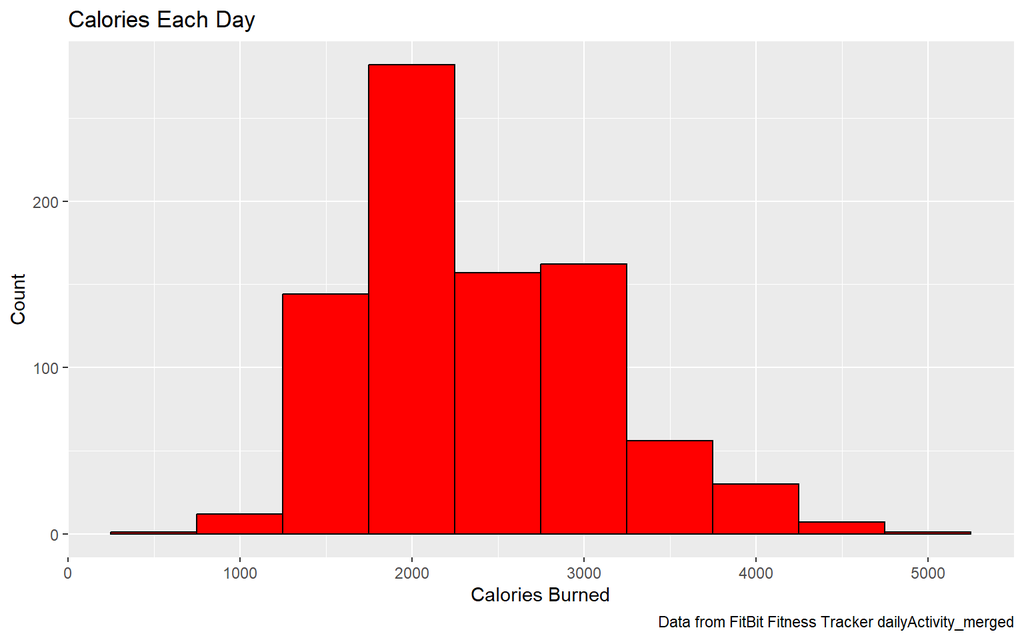

```r
ggplot(data = realActivity) +
  geom_histogram(mapping=aes(x=Calories),binwidth = 500,color="black",fill="red")+
  labs(title="Calories Each Day", caption = "Data from FitBit Fitness Tracker dailyActivity_merged",x="Calories Burned",y="Count")
```

```r
summary(realActivity$Calories)
```

```
##    Min. 1st Qu.  Median    Mean 3rd Qu.    Max.
##     741    1868    2225    2376    2840    4900
```

While no calorie intake data was collected, **the advertising department could claim that fitness tracker wearing indivduals typically burn more than 2200 calories a day, the number of recommended intake calories by the [US Dietary Guidelines](https://health.gov/sites/default/files/2019-09/2015-2020_Dietary_Guidelines.pdf)**.

As suspected, participants who took more steps daily tended to burn more calories. This can be seen in the two plots below. The first plot shows number of steps taken and number of calories burned faceted by particpant id:

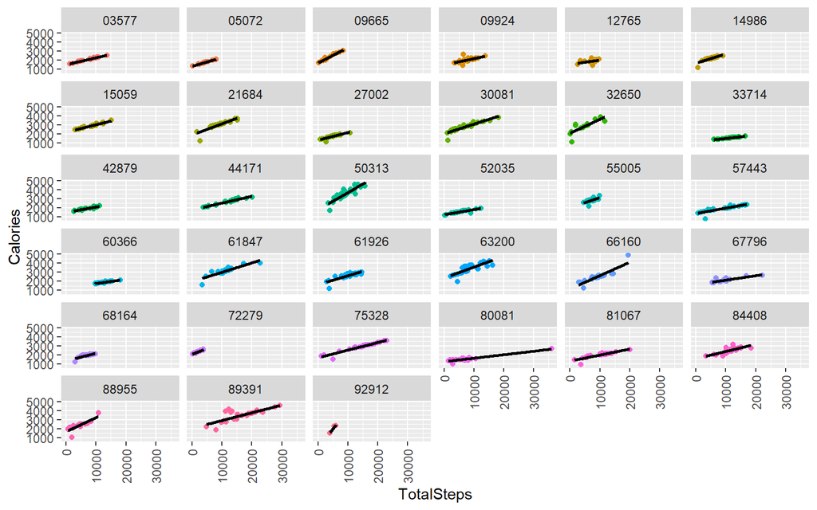

```r
ggplot(data=realActivity) +
  geom_point(mapping=aes(x=TotalSteps,y=Calories,color=NewId))+
  geom_smooth(mapping=aes(x=TotalSteps,y=Calories),se=FALSE,method="lm",color="black")+
  facet_wrap(vars(NewId))+
  theme(legend.position = "none")+
  guides(x = guide_axis(angle = 90))
```

The second shows the total number steps taken and number of calories burned by each participant on the same plot:

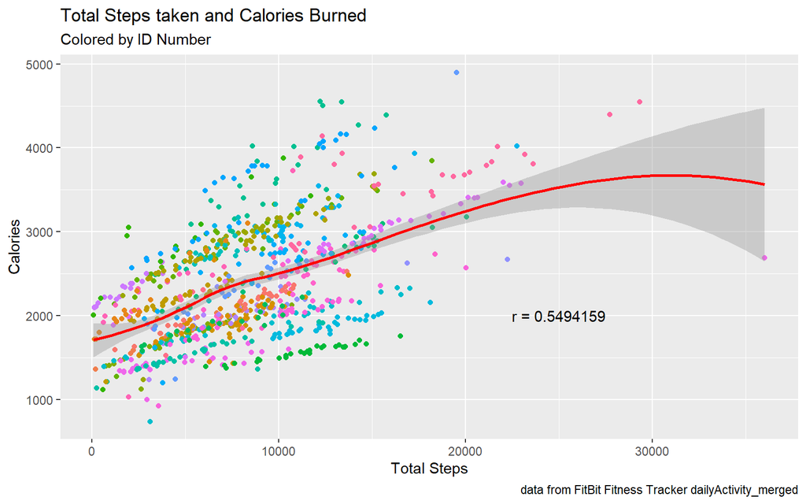

```r
ggplot(data=realActivity) +
  geom_point(mapping=aes(x=TotalSteps,y=Calories,color=NewId))+
  geom_smooth(mapping=aes(x=TotalSteps,y=Calories,),color="red")+
  theme(legend.position = "none")+
  labs(title="Total Steps taken and Calories Burned",subtitle = "Colored by ID Number",caption="data from FitBit Fitness Tracker dailyActivity_merged", x="Total Steps")+
  annotate(geom="text",label="r = 0.5494159",x=25000,y=2000)
```

```r
cor(realActivity$TotalSteps,realActivity$Calories)
```

```
## [1] 0.5494159
```

As seen in the second plot, a there is a clear correlation between number of steps taken and calories burned, with a correlation coefficient of r = 0.5494. **This further places importance on the effect of wearing a fitness tracker, and it’s link to a healthy lifestyle. This should be heavily advertised by BellaBeat**

### Sleep Analysis

Sleep is an extremely important aspect of human health. While the number of steps clearly impacts burning calories, the connection between the total number of steps and number of sleep minutes is not as clear. Below is a scatterplot showing this:

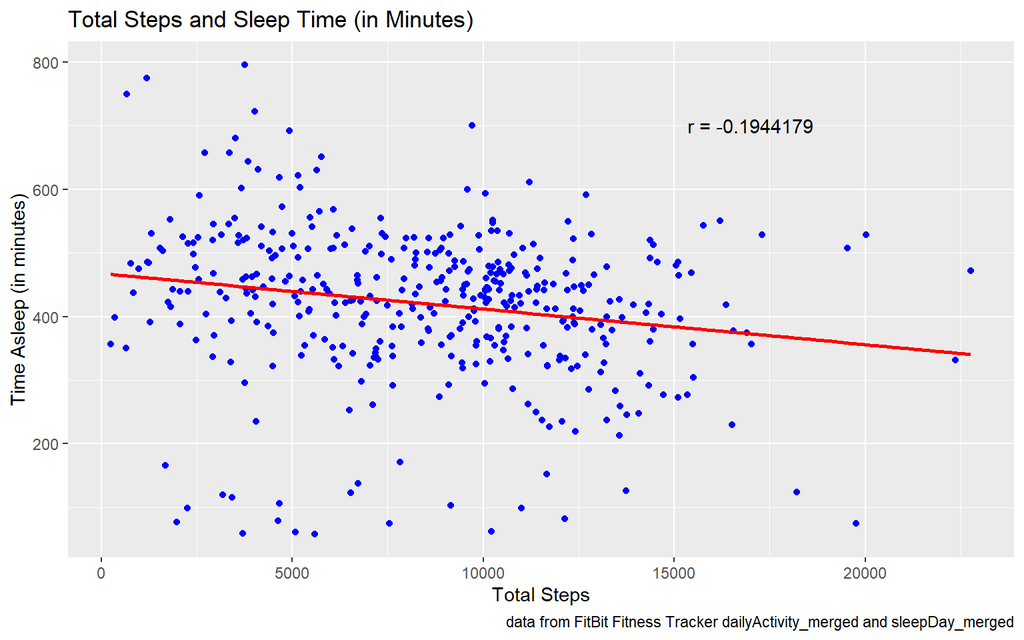

```r
ggplot(data = SleepActivity)+
  geom_point(mapping=aes(x=TotalSteps,y=sleepTime),color="blue")+
  geom_smooth(mapping=aes(x=TotalSteps,y=sleepTime),color="red",method="lm",se=FALSE)+
  labs(title="Total Steps and Sleep Time (in Minutes)",caption="data from FitBit Fitness Tracker dailyActivity_merged and sleepDay_merged",x="Total Steps",y="Time Asleep (in minutes)")+
  annotate(geom="text",label= "r = -0.1944179", x=17000,y=700)
```

```r
cor(SleepActivity$TotalSteps,sleepTime)
```

```
## [1] -0.1944179
```

This plot suprisingly shows a *negative* correlation between steps and sleep. This seems counter-intuitive, so further analysis is required. The amount of time that each fitness tracker recorded that the participant was sedentary is plotted against sleep time, and a more clear correlation can be observed:

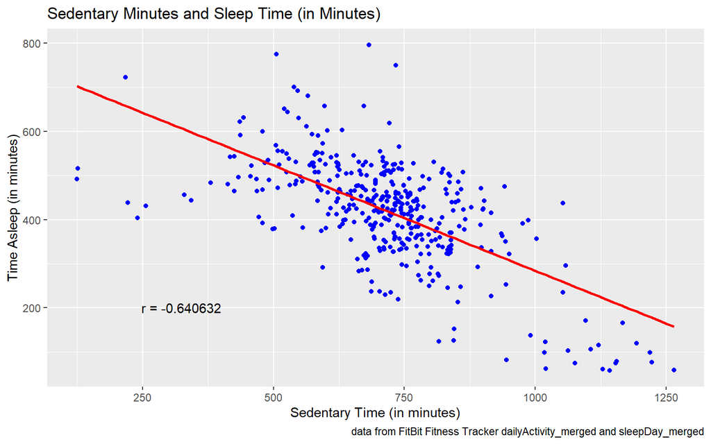

```r
ggplot(data = SleepActivity)+
  geom_point(mapping=aes(x=sedmin,y=sleepTime),color="blue")+
  geom_smooth(mapping=aes(x=sedmin,y=sleepTime),color="red",method="lm",se=FALSE)+
  labs(title="Sedentary Minutes and Sleep Time (in Minutes)",caption="data from FitBit Fitness Tracker dailyActivity_merged and sleepDay_merged",x="Sedentary Time (in minutes)",y="Time Asleep (in minutes)")+
  annotate(geom="text",label= "r = -0.640632", x=325,y=200)
```

```r
cor(sedmin,sleepTime)
```

```
## [1] -0.6406326
```

```r
reg <- lm(sedmin ~ sleepTime,data = SleepActivity)
reg
```

```
##
## Call:
## lm(formula = sedmin ~ sleepTime, data = SleepActivity)
##
## Coefficients:
## (Intercept)    sleepTime
##   1075.8918      -0.8582
```

```r
(420-1075.8918)/-0.8582
```

```
## [1] 764.2645
```

### Excerise Intensity

Participant exercise was analyzed by considering the “Total Intensity” recorded. Below is a plot that shows individual particpant excercise over time:

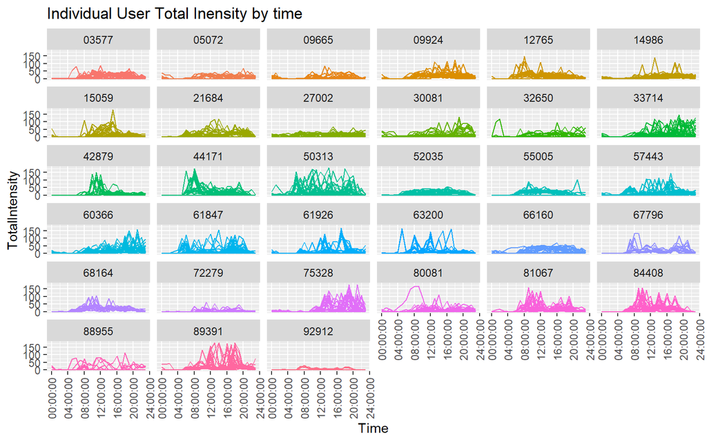

```r
ggplot(data=timeIntensities)+
  geom_line(mapping=aes(x=Time,y=TotalIntensity,group=ADate,color=NewId))+
  facet_wrap(vars(NewId))+
  theme(legend.position = "none")+
  labs(title="Individual User Total Inensity by time")+
  guides(x = guide_axis(angle = 90))
```

While a few of the participants seem to have active times in the morning, more of them appear to be active in the afternoon. The plot below confirms this:

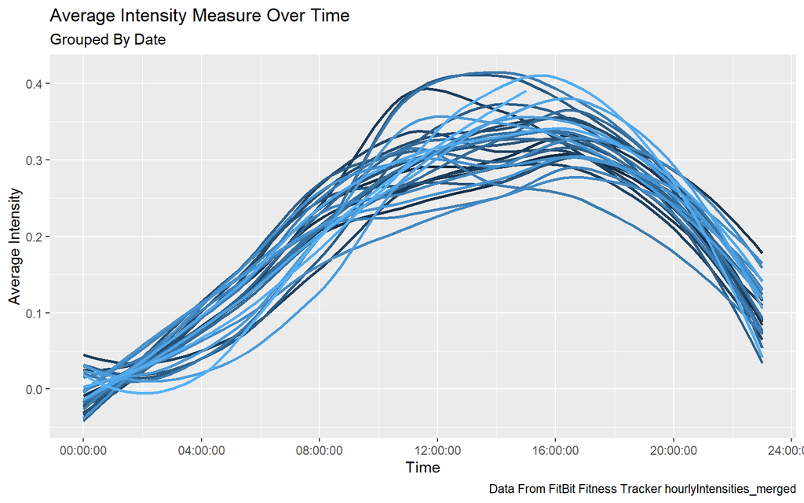

```r
ggplot(data=timeIntensities)+
  geom_smooth(mapping=aes(x=Time,y=AverageIntensity, group=ADate,color=ADate),se=FALSE)+
  theme(legend.position = "none")+
  labs(title="Average Intensity Measure Over Time",subtitle="Grouped By Date",y="Average Intensity",caption="Data From FitBit Fitness Tracker hourlyIntensities_merged")
```

# Conclusions

BellaBeat’s Marketing should focus on three key takeaways from this data.

BellaBeat should also consider implementing a movement reminder in their wearable devices and app to reduce sedentary time and improve sleep time.

# Appendix

### Data Sets:

[FitBit Fitness Tracker Data](https://www.kaggle.com/datasets/arashnic/fitbit) (CC0: Public Domain, dataset made available through [Mobius](https://www.kaggle.com/arashnic))

- dailyActivity_merged
- sleepDay_merged
- timeIntensities

### Change Log

[Change log link](https://drive.google.com/file/d/1_m1rIY89HJu7G8qTNxAZcDJwsQNE5lnT/view?usp=share_link)

### References

- [John Hopkins Medincine’s Report: could a fitness tracker boost your heart health?](https://www.hopkinsmedicine.org/health/wellness-and-prevention/could-a-fitness-tracker-boost-your-heart-health#:~:text=A%20fitness%20tracker%20may%20help,a%20heart%2Dsmart%20daily%20goal.)
- “The Lancet: Daily Steps and all-cause Mortality: a meta-analysis of 15 international cohorts”
- [US Dietary Guidelines](https://health.gov/sites/default/files/2019-09/2015-2020_Dietary_Guidelines.pdf)
- [CDC: How much sleep do I need?](https://www.cdc.gov/sleep/about_sleep/how_much_sleep.html)